# Technical & Implementation Issues

Carson J. Q. Farmer  
[@carsonfarmer](http://www.twitter.com/carsonfarmer/)  
[http://carsonfarmer.com/](http://www.carsonfarmer.com)  
[Presentation code](https://github.com/cfarmer/aag_2014/blob/master/open_gis/index.md)

[figure not shown]

## Who am I?

## By day

- Assistant Professor of GIScience (Hunter College, CUNY)
- Associate Director of [CARSI](http://www.carsilab.org/) lab
- In the process of developing a new MGIS program*
- (Re)developing FOSS Geospatial Masterclass

## By Night

- Python hacker and developer
- Worked on [QGIS](http://www.qgis.org) project since 2007
- Developed fTools (aka QGIS 'Vector' menu)
- Currently working on [GeoPandas](https://www.github.com/kjordahl/geopandas) with Kelsey Jordahl

# User Developer Educator Scientist

## ask not what open culture can do for GIS, ask what GIS can do for open culture

## Plenty of New Opportunities

- Pretty clear that GIS "culture" can benefit from Open "culture"
- GIS is technology driven - So is open culture
  - Open Source
  - Open Standards
  - Open Data
  - Open Science

## What Do We Bring to the Table? (How Do We Further the 'Open Agenda'?)

## User

## What Do We Bring To Users?

- Geospatial capabilities
- Spatial databases
- Data formats & standards
- **Community**
- Data (New York Example)

## NYC Open Data

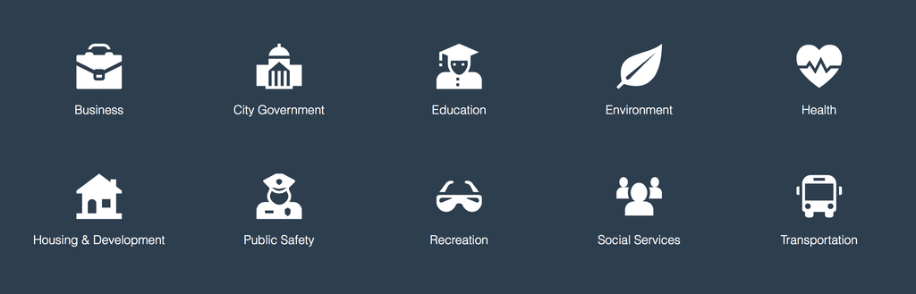

+1100 Datasets (many with geo information) of which 638 are maps!

## Challenges

- Installation/linking of geo libraries
  - OSGEO4W
  - OSGEO4Mac
  - UbuntuGIS
  - OpenGeoSuite
- **Marketing?**

## Developer

## Opportunities

- Speed, Multiprocessing, Big Data, UX & Design, Cloud Computing, Distributed Computing, Web vs Desktop, Interoperability, etc
- GeoJSON taking over the web
- Linked Open Data
  - GIScience can/should play key role
  - Space becomes ultimate indexing system

## Code!

- Exciting things happening with [Python](http://www.spatiallyadjusted.com/2011/01/03/2011-the-year-python-takes-over-gis/)...
- Critical mass of devs and libraries continuing to develop
  - ESRI, QGIS, GRASS, etc...
  - PySAL, STARS, GeoPandas
  - Fiona, Shapely, Rasterio
  - Sean Gillies' [geo interface](http://sgillies.net/blog/1185/geojson-and-the-geo-interface-for-python)

## Educator

## Questions

- How to attract students with computational literacy?
- *Should* they know how to code?
- Do they *need* to know how to code?
- Open GIS is about a lot more than Open Source, Specifications, and Technical bits...

## Recent Survey

- We want proprietary experts today...
- We open GIS experts in 3-5 years...
- And we want them *trained in both* now...
- Oh, and they should all be able to read code.

## Do They *Need* to Know?

- Source Code
- Open Specifications
- Open Licensing
- Open Data
- Open Content

## Scientist

## Doing Science

- CARSI has a copter "drone"
  - Software is open
  - Hardware is open
  - 3D model for parts is open

## Obstacles

- Still desktop focused?
- Publication credit
- Uncertainty
- **Reproducibility**
- Spatial algorithms
- Spatial data (and standards)
- Libraries and frameworks
- **Integration**

# Thanks!

[@carsonfarmer](http://www.twitter.com/carsonfarmer/)  
[http://carsonfarmer.com/](http://www.carsonfarmer.com)  
[Presentation code](https://github.com/cfarmer/aag_2014/blob/master/open_gis/index.md)  
Carson J. Q. Farmer

Department of Geography  
Hunter College - CUNY  
695 Park Avenue  
New York, NY, 10065

[figure not shown]